# cardinal fitness — results summaries

## Statistical Methods

All analyses were performed in R (v4.5.2). Fecundity (egg counts) was modelled using a zero-inflated negative binomial (nbinom1) mixed model fitted with glmmTMB, with genetic line, cross and their interaction as fixed effects, an intercept-only zero-inflation component, and replicate and plate well as nested random effects. Hatching rate was modelled using a binomial generalised linear mixed model (GLMM), also fitted with glmmTMB. Estimated marginal means and contrasts were obtained using emmeans; each genotype is compared with the wildtype (WT) group of the same line (treatment-versus-control, Dunnett-adjusted within line). Post-blood-feeding survival, trans-heterozygote survival, and XA supplementation survival data were modelled using Weibull parametric survival models fitted with flexsurv. Groups in which no female died have no estimable time ratio (complete separation) and, if included, corrupt flexsurv’s standard errors for every other group; these groups were fitted out of the Weibull models, shown by Kaplan–Meier curves only, and compared using log-rank tests. Time ratios against each line’s WT siblings were computed from the model coefficients and covariance matrix (Holm-adjusted within line). XA supplementation was analysed separately for each supplementation route (each treatment within a route was a single cage), using heterozygotes only, with the pooled model and an arm × treatment test as supporting evidence. Midgut integrity (smurf assay) and adult eclosion data were modelled using binomial generalised linear models (GLMs) fitted with base R glm(). Gene expression data were analysed using the delta-delta-Ct method; ΔCt levels were modelled with a permutation-based linear model using emmeans for contrasts. Model tables were produced using sjPlot. Survival curves were visualised using Kaplan–Meier estimates alongside Weibull model predictions. All figures were produced using ggplot2 and patchwork.

## Manuscript items in this report

Each table and figure below is labelled with the manuscript item it supplies. The labels mean:

- **(new)**: added in response to the reviewers.
- **Superseded**: kept for reference only; do not use in the supplement.
- **Text values**: the source of numbers quoted in the Results, not itself a supplementary table.

| Manuscript item | Content | Section of this report |
| --- | --- | --- |
| Table 1 (new, main text) | Direction and significance of each trait relative to WT | Table 1 and STable S_fitness |
| STable 1 | Larva-to-adult survival | Larva-to-adult survival |
| STable 2 | Engorgement and survival numbers | Not generated here (summary sheets in `data/FertilityData.xlsx`) |
| STable 3 | Fecundity | Fecundity |
| STable 4 | Fertility (hatching) | Fertility |
| STable 5 | Survival after blood feeding | Survival after blood feeding |
| STable 6 | Smurf assay | Smurf assay |
| STable 7 | XA supplementation | XA supplementation |
| STable 8 | Trans-heterozygote survival | Trans-heterozygote survival |
| STable S_fitness (new) | Observed values, ratios, 95% CIs and p-values behind Table 1 | Table 1 and STable S_fitness |
| Statistics for Fig. 6 / SFig. 5 (suggested new STable) | qPCR contrasts | qPCR |

Figures 1–6, SFig. 3 and SFig. 5 are labelled where they appear; exported versions are in `outputs/figures/`.

### Panel-by-panel key to `Supplementary information_Rev.docx`

The panel letters used in this report (for example “STable 3c”) are the same letters used in the supplementary document, so “STable 3c” here is panel C of STable 3 there. Checked on 2026-11-10 by comparing the numbers in the supplementary document with the output of the current code (STables 3 and 1 were re-run; the rest were compared with the rendered report).

| STable | Panels in this report | Panels in the supplementary document | Match |
| --- | --- | --- | --- |
| 1 Larva-to-adult | 1a observed; 1b Dunnett vs WT; 1c GLM coefficients; 1d genotype (Tukey); 1e line comparisons | A observed; B Dunnett; C coefficients (raw sjPlot copy); D genotype (Tukey); E coefficients again (clean copy) | Numbers match. **Panel E differs** (see below) |
| 2 Engorgement | not generated | single table | Not applicable |
| 3 Fecundity | 3a coefficients; 3b estimated means; 3c line within cross; 3d cross within line; 3e Dunnett vs WT; 3f observed | A to F, same order | Numbers match |
| 4 Hatching | 4a coefficients; 4b estimated means; 4c line within cross; 4d cross within line; 4e Dunnett vs WT | A to E, same order | Numbers match |
| 5 Blood-feeding survival | 5a Weibull model; 5b vs WT siblings; 5c median survival; 5d survival at 300 h | A to D, same order | Numbers match. Caption n differs |
| 6 Smurf | 6a GLM; 6b proportions; 6c deaths; 6d survival by Smurf status | A to D, same order | Numbers match |
| 7 XA supplementation | 7a counts; 7b per-route contrasts; 7c likelihood-ratio tests; 7d pooled; 7e survival at 72 h | A to E, same order | Numbers match. The superseded pooled model is correctly absent |
| 8 Trans-heterozygotes | 8a Weibull model; 8b vs WT and trans-het vs het; 8c survival at 100 h | A to C, same order | Numbers match |
| Not in the supplementary document | Table 1, STable S_fitness, qPCR statistics | none | Still to be added |

### Differences found, and why

1. **STable 1, panel E.** The supplementary document shows the coefficient table twice (panels C and E); the line-comparison table (1e here, the source of OR = 1.22, p = 0.157) is missing, although the caption promises it. Cause: the clean coefficient table was probably pasted in place of 1e. Fix: replace panel E with 1e, and keep one coefficient table (panel C has a raw `cbind(...)` header and broken labels).
2. **STable 5 caption.** The caption gives n = 327, but the model table and this report give 337 (all groups except the 47 `cd`<sup>g338-384</sup> WT females, which are fitted out). The caption is a typo.
3. **STable 3 caption.** It says “egg count per well”, while 3b and Figure 1A here say “eggs per female”. Use one wording, after confirming that a well holds one female.
4. **STable 4 caption.** It says “all comparisons are relative to WT (A)”. Panel A is relative to the *cd*<sup>384R</sup> SDA-500 × SDA-500 group; comparisons against each line’s own WT are in panel E.
5. **STable 6.** The supplementary document labels the terms by allele (cdg225, cd225R) and this report by KI/KO; wording only. The Fisher’s exact test for the non-estimable KO term is not in the supplementary document.
6. **STable 8 caption.** It describes a model with Het, Hom and WT genotypes and does not mention that the cd225R heterozygotes (no deaths) are fitted out of the model, or that panel B is Holm-adjusted.
7. **SFig. 5 caption.** It says “permuted t-test”; the analysis is now a Freedman–Lane permutation test of ΔCt within sex (corrected 2026-11-06). The caption should be updated with the qPCR statistics table.
8. **Labels in STables 3 and 4.** The intercept label here now reads *cd*<sup>384R</sup>, as in the supplementary document (it previously used the internal code). The odd extra “Intercept” row with IRR 9,534,217 in STable 3a appears identically in both, so it is not a transcription error. Its origin (probably the dispersion parameter printed by sjPlot) has not been checked.
9. **Why fecundity statistics seem to differ from the earlier version.** The model, the estimated means (3b) and the pairwise contrasts (3c, 3d) are identical to the earlier render. What changed is that 3e (Dunnett, each cross against its own line’s WT) was added. It differs from 3d because it compares fewer pairs (so a smaller multiplicity penalty), and its ratios are the inverse of the “WT − cross” rows in 3d (for example 1.31 against 0.76 for *cd*<sup>384R</sup> female HET, z = 2.19 in both, p = 0.097 against 0.184). 3f (observed counts) was also added, and Figure 1A was redrawn.

## Fecundity (STable 3; Fig. 1A)

**STable 3a.** Fecundity: model coefficients (zero-inflated negative binomial GLMM).

|  | eggs |  |  |  |
| --- | --- | --- | --- | --- |
| Predictors | Incidence Rate Ratios | CI | p |  |
| Count Model |  |  |  |  |
| Intercept (*cd*<sup>384R</sup>, SDA×SDA) | 76.59 | 62.78 – 93.45 | **<0.001** |  |
| *cd*<sup>g225</sup> | 1.09 | 0.85 – 1.41 | 0.490 |  |
| *cd*<sup>g384</sup> | 1.48 | 1.18 – 1.85 | **0.001** |  |
| Female Het | 1.31 | 1.03 – 1.67 | **0.029** |  |
| Male Het | 1.12 | 0.86 – 1.46 | 0.416 |  |
| Female Hom | 1.43 | 1.09 – 1.88 | **0.009** |  |
| Male Hom | 0.74 | 0.53 – 1.04 | 0.084 |  |
| *cd*<sup>g225</sup> × Female Het | 1.00 | NaN – NaN | NaN |  |
| *cd*<sup>g384</sup> × Female Het | 0.63 | 0.47 – 0.86 | **0.004** |  |
| *cd*<sup>g225</sup> × Male Het | 0.90 | 0.62 – 1.31 | 0.569 |  |
| *cd*<sup>g384</sup> × Male Het | 0.80 | 0.59 – 1.10 | 0.177 |  |
| *cd*<sup>g384</sup> × Female Hom | 0.41 | 0.28 – 0.59 | **<0.001** |  |
| *cd*<sup>g384</sup> × Male Hom | 0.79 | 0.50 – 1.25 | 0.316 |  |
| Intercept (*cd*<sup>384R</sup>, SDA×SDA) | 9534217.44 | 196910.85 – 1587058406.93 |  |  |
| Zero-Inflated Model |  |  |  |  |
| Intercept (*cd*<sup>384R</sup>, SDA×SDA) | 0.47 | 0.39 – 0.56 | **<0.001** |  |
| Random Effects |  |  |  |  |
| σ<sup>2</sup> |  |  |  |  |
| τ<sub>00</sub> <sub>plate_well:rep</sub> | 0.05 |  |  |  |
| τ<sub>00</sub> <sub>rep</sub> | 0.00 |  |  |  |
| N <sub>plate_well</sub> | 506 |  |  |  |
| N <sub>rep</sub> | 10 |  |  |  |
| Observations | 546 |  |  |  |

**STable 3b.** Estimated eggs per female: conditional (non-zero) mean, and expected count including zeros.

| Line | Cross | Non-zero wells Conditional mean | Non-zero wells Lower 95% CI | Non-zero wells Upper 95% CI | Expected count (incl. zeros)<sup>1</sup> |  |
| --- | --- | --- | --- | --- | --- | --- |
| *cd*<sup>384R</sup> | WT | 76.6 | 62.8 | 93.4 |  | 52.2 |
| *cd*<sup>g225</sup> | WT | 83.7 | 71.6 | 97.9 | 57.0 |  |
| *cd*<sup>g384</sup> | WT | 113.4 | 102.2 | 125.9 | 77.3 |  |
| *cd*<sup>384R</sup> | Female HET | 100.5 | 87.1 | 115.8 | 68.4 |  |
| *cd*<sup>g225</sup> | Female HET | 109.7 | NaN | NaN | 74.8 |  |
| *cd*<sup>g384</sup> | Female HET | 94.4 | 80.1 | 111.2 | 64.3 |  |
| *cd*<sup>384R</sup> | Male HET | 85.5 | 71.6 | 102.2 | 58.3 |  |
| *cd*<sup>g225</sup> | Male HET | 83.8 | 67.5 | 104.0 | 57.1 |  |
| *cd*<sup>g384</sup> | Male HET | 101.8 | 88.4 | 117.2 | 69.4 |  |
| *cd*<sup>384R</sup> | Female HOM | 109.9 | 91.1 | 132.4 | 74.8 |  |
| *cd*<sup>g225</sup> | Female HOM | NA | NA | NA | NA |  |
| *cd*<sup>g384</sup> | Female HOM | 66.5 | 53.2 | 83.2 | 45.3 |  |
| *cd*<sup>384R</sup> | Male HOM | 56.9 | 43.4 | 74.7 | 38.8 |  |
| *cd*<sup>g225</sup> | Male HOM | NA | NA | NA | NA |  |
| *cd*<sup>g384</sup> | Male HOM | 66.7 | 49.9 | 89.3 | 45.5 |  |

<sup>1</sup> Structural zero probability = 0.319; expected count = conditional mean × (1 − p_zero)

**STable 3c.** Line comparisons within each cross. This is the source of the female-heterozygote contrast in comments 9 and 10 (z = 0.57, p = 0.57).

| Line comparisons within cross Contrast | Line comparisons within cross Cross | Line comparisons within cross IRR | Line comparisons within cross Lower 95% CI | Line comparisons within cross Upper 95% CI | Line comparisons within cross z | Line comparisons within cross p |
| --- | --- | --- | --- | --- | --- | --- |
| *cd*<sup>384R</sup> - *cd*<sup>g225</sup> | WT | 0.91 | 0.71 | 1.18 | −0.69 | 0.769 |
| *cd*<sup>384R</sup> - *cd*<sup>g384</sup> | WT | 0.68 | 0.54 | 0.84 | −3.45 | 0.002 |
| *cd*<sup>g225</sup> - *cd*<sup>g384</sup> | WT | 0.74 | 0.61 | 0.89 | −3.19 | 0.004 |
| *cd*<sup>384R</sup> - *cd*<sup>g384</sup> | Female HET | 1.06 | 0.86 | 1.32 | 0.57 | 0.568 |
| *cd*<sup>384R</sup> - *cd*<sup>g225</sup> | Male HET | 1.02 | 0.77 | 1.35 | 0.14 | 0.989 |
| *cd*<sup>384R</sup> - *cd*<sup>g384</sup> | Male HET | 0.84 | 0.67 | 1.05 | −1.52 | 0.283 |
| *cd*<sup>g225</sup> - *cd*<sup>g384</sup> | Male HET | 0.82 | 0.64 | 1.06 | −1.49 | 0.297 |
| *cd*<sup>384R</sup> - *cd*<sup>g384</sup> | Female HOM | 1.65 | 1.24 | 2.21 | 3.40 | <0.001 |
| *cd*<sup>384R</sup> - *cd*<sup>g384</sup> | Male HOM | 0.85 | 0.57 | 1.27 | −0.78 | 0.433 |

**STable 3d.** Cross comparisons within each line.

| Cross comparisons within line Contrast | Cross comparisons within line Line | Cross comparisons within line IRR | Cross comparisons within line Lower 95% CI | Cross comparisons within line Upper 95% CI | Cross comparisons within line z | Cross comparisons within line p |
| --- | --- | --- | --- | --- | --- | --- |
| WT - Female HET | *cd*<sup>384R</sup> | 0.76 | 0.60 | 0.97 | −2.19 | 0.184 |
| WT - Male HET | *cd*<sup>384R</sup> | 0.90 | 0.69 | 1.17 | −0.81 | 0.927 |
| WT - Female HOM | *cd*<sup>384R</sup> | 0.70 | 0.53 | 0.91 | −2.60 | 0.070 |
| WT - Male HOM | *cd*<sup>384R</sup> | 1.35 | 0.96 | 1.88 | 1.73 | 0.415 |
| Female HET - Male HET | *cd*<sup>384R</sup> | 1.17 | 0.94 | 1.47 | 1.40 | 0.630 |
| Female HET - Female HOM | *cd*<sup>384R</sup> | 0.91 | 0.72 | 1.15 | −0.75 | 0.943 |
| Female HET - Male HOM | *cd*<sup>384R</sup> | 1.77 | 1.30 | 2.40 | 3.63 | 0.003 |
| Male HET - Female HOM | *cd*<sup>384R</sup> | 0.78 | 0.60 | 1.01 | −1.91 | 0.310 |
| Male HET - Male HOM | *cd*<sup>384R</sup> | 1.50 | 1.09 | 2.08 | 2.46 | 0.100 |
| Female HOM - Male HOM | *cd*<sup>384R</sup> | 1.93 | 1.39 | 2.68 | 3.91 | <0.001 |
| WT - Male HET | *cd*<sup>g225</sup> | 1.00 | 0.77 | 1.30 | −0.01 | 0.994 |
| WT - Female HET | *cd*<sup>g384</sup> | 1.20 | 0.99 | 1.45 | 1.88 | 0.325 |
| WT - Male HET | *cd*<sup>g384</sup> | 1.11 | 0.94 | 1.32 | 1.23 | 0.737 |
| WT - Female HOM | *cd*<sup>g384</sup> | 1.70 | 1.34 | 2.18 | 4.28 | <0.001 |
| WT - Male HOM | *cd*<sup>g384</sup> | 1.70 | 1.25 | 2.31 | 3.37 | 0.007 |
| Female HET - Male HET | *cd*<sup>g384</sup> | 0.93 | 0.75 | 1.15 | −0.69 | 0.958 |
| Female HET - Female HOM | *cd*<sup>g384</sup> | 1.42 | 1.08 | 1.87 | 2.49 | 0.092 |
| Female HET - Male HOM | *cd*<sup>g384</sup> | 1.41 | 1.01 | 1.97 | 2.04 | 0.248 |
| Male HET - Female HOM | *cd*<sup>g384</sup> | 1.53 | 1.18 | 1.99 | 3.18 | 0.013 |
| Male HET - Male HOM | *cd*<sup>g384</sup> | 1.53 | 1.10 | 2.11 | 2.56 | 0.077 |
| Female HOM - Male HOM | *cd*<sup>g384</sup> | 1.00 | 0.69 | 1.44 | −0.02 | 1.000 |

**STable 3e (new; comment 5).** Each cross versus the WT group of the same line (Dunnett).

| Each cross versus WT of the same line Line | Each cross versus WT of the same line Contrast | Each cross versus WT of the same line IRR | Each cross versus WT of the same line Lower 95% CI | Each cross versus WT of the same line Upper 95% CI | Each cross versus WT of the same line z | Each cross versus WT of the same line p (Dunnett) |
| --- | --- | --- | --- | --- | --- | --- |
| *cd*<sup>384R</sup> | Female HET - WT | 1.31 | 1.03 | 1.67 | 2.19 | 0.097 |
| *cd*<sup>384R</sup> | Male HET - WT | 1.12 | 0.86 | 1.46 | 0.81 | 0.794 |
| *cd*<sup>384R</sup> | Female HOM - WT | 1.43 | 1.09 | 1.88 | 2.60 | 0.033 |
| *cd*<sup>384R</sup> | Male HOM - WT | 0.74 | 0.53 | 1.04 | −1.73 | 0.251 |
| *cd*<sup>g225</sup> | Male HET - WT | 1.00 | 0.77 | 1.31 | 0.01 | 0.994 |
| *cd*<sup>g384</sup> | Female HET - WT | 0.83 | 0.69 | 1.01 | −1.88 | 0.187 |
| *cd*<sup>g384</sup> | Male HET - WT | 0.90 | 0.76 | 1.07 | −1.23 | 0.539 |
| *cd*<sup>g384</sup> | Female HOM - WT | 0.59 | 0.46 | 0.75 | −4.28 | <0.001 |
| *cd*<sup>g384</sup> | Male HOM - WT | 0.59 | 0.43 | 0.80 | −3.37 | 0.003 |

**STable 3f (new; comment 6).** Observed egg counts and proportion of females laying any eggs.

| Line | Cross | Females | Mean eggs | Median eggs | Laid any eggs |
| --- | --- | --- | --- | --- | --- |
| *cd*<sup>384R</sup> | WT | 35 | 57.9 | 48.0 | 71% |
| *cd*<sup>384R</sup> | Female HET | 46 | 89.5 | 91.0 | 89% |
| *cd*<sup>384R</sup> | Male HET | 39 | 66.7 | 74.0 | 74% |
| *cd*<sup>384R</sup> | Female HOM | 35 | 69.2 | 77.0 | 63% |
| *cd*<sup>384R</sup> | Male HOM | 29 | 38.1 | 17.0 | 59% |
| *cd*<sup>g225</sup> | WT | 95 | 35.4 | 0.0 | 40% |
| *cd*<sup>g225</sup> | Female HET | 1 | 0.0 | 0.0 | 0% |
| *cd*<sup>g225</sup> | Male HET | 39 | 45.2 | 2.0 | 51% |
| *cd*<sup>g384</sup> | WT | 75 | 109.3 | 113.0 | 96% |
| *cd*<sup>g384</sup> | Female HET | 39 | 77.1 | 90.0 | 82% |
| *cd*<sup>g384</sup> | Male HET | 48 | 89.4 | 98.5 | 85% |
| *cd*<sup>g384</sup> | Female HOM | 28 | 53.7 | 51.5 | 79% |
| *cd*<sup>g384</sup> | Male HOM | 37 | 25.5 | 0.0 | 35% |

The zero-inflation component is intercept-only, so the model assumes the same proportion of non-laying females in every group; observed proportions range widely.

**Figure 1A** (panel; the full Figure 1 is at the end of the Fertility section).

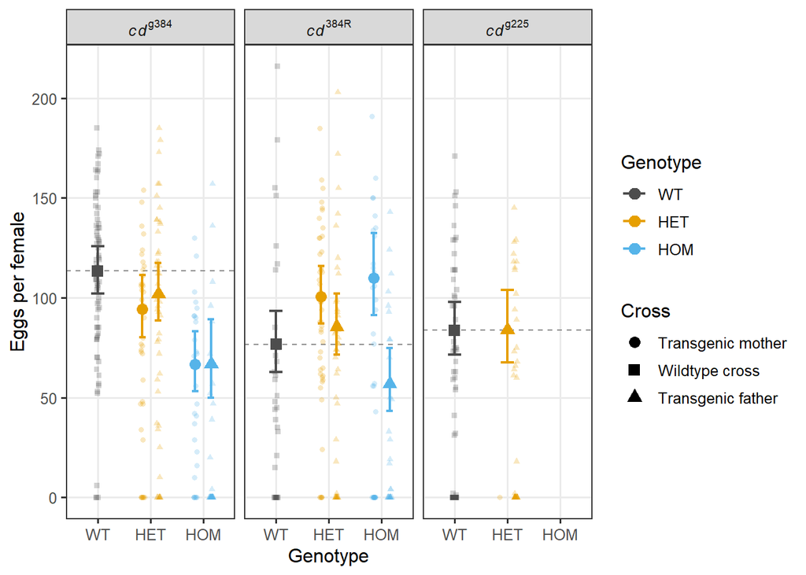

## Fertility (STable 4; Fig. 1B)

**STable 4a.** Hatching: model coefficients (binomial GLMM).

|  | cbind(larvae,(eggs-larvae)) |  |  |
| --- | --- | --- | --- |
| Predictors | Odds Ratios | CI | p |
| Intercept (*cd*<sup>384R</sup>, SDA×SDA) | 4.21 | 2.16 – 8.22 | **<0.001** |
| *cd*<sup>g225</sup> | 0.88 | 0.37 – 2.09 | 0.772 |
| *cd*<sup>g384</sup> | 1.28 | 0.59 – 2.77 | 0.539 |
| Female Het | 4.51 | 1.91 – 10.65 | **0.001** |
| Male Het | 2.02 | 0.81 – 5.07 | 0.132 |
| Female Hom | 2.96 | 1.11 – 7.88 | **0.030** |
| Male Hom | 1.92 | 0.66 – 5.61 | 0.230 |
| *cd*<sup>g384</sup> × Female Het | 0.15 | 0.05 – 0.45 | **0.001** |
| line2360B5:crossMale HET | 0.37 | 0.10 – 1.35 | 0.131 |
| *cd*<sup>g384</sup> × Male Het | 0.31 | 0.10 – 0.96 | **0.043** |
| *cd*<sup>g384</sup> × Female Hom | 0.00 | 0.00 – 0.01 | **<0.001** |
| *cd*<sup>g384</sup> × Male Hom | 0.30 | 0.07 – 1.31 | 0.108 |
| Random Effects |  |  |  |
| σ<sup>2</sup> | 2.76 |  |  |
| τ<sub>00</sub> <sub>plate_well:rep:line</sub> | 2.72 |  |  |
| τ<sub>00</sub> <sub>rep:line</sub> | 0.00 |  |  |
| τ<sub>00</sub> <sub>line</sub> | 0.00 |  |  |
| N <sub>plate_well</sub> | 424 |  |  |
| N <sub>rep</sub> | 10 |  |  |
| N <sub>line</sub> | 3 |  |  |
| Observations | 449 |  |  |
| Marginal R<sup>2</sup> / Conditional R<sup>2</sup> | 0.323 / NA |  |  |

**STable 4b.** Estimated hatching probabilities.

| Line | Cross | Estimated marginal means Hatching probability | Estimated marginal means Lower 95% CI | Estimated marginal means Upper 95% CI |
| --- | --- | --- | --- | --- |
| *cd*<sup>384R</sup> | WT | 0.808 | 0.683 | 0.892 |
| *cd*<sup>g225</sup> | WT | 0.787 | 0.681 | 0.865 |
| *cd*<sup>g384</sup> | WT | 0.843 | 0.784 | 0.888 |
| *cd*<sup>384R</sup> | Female HET | 0.950 | 0.917 | 0.970 |
| *cd*<sup>g225</sup> | Female HET | NA | NA | NA |
| *cd*<sup>g384</sup> | Female HET | 0.781 | 0.665 | 0.865 |
| *cd*<sup>384R</sup> | Male HET | 0.895 | 0.820 | 0.941 |
| *cd*<sup>g225</sup> | Male HET | 0.733 | 0.563 | 0.853 |
| *cd*<sup>g384</sup> | Male HET | 0.773 | 0.671 | 0.851 |
| *cd*<sup>384R</sup> | Female HOM | 0.926 | 0.859 | 0.962 |
| *cd*<sup>g225</sup> | Female HOM | NA | NA | NA |
| *cd*<sup>g384</sup> | Female HOM | 0.048 | 0.022 | 0.101 |
| *cd*<sup>384R</sup> | Male HOM | 0.890 | 0.779 | 0.949 |
| *cd*<sup>g225</sup> | Male HOM | NA | NA | NA |
| *cd*<sup>g384</sup> | Male HOM | 0.754 | 0.541 | 0.888 |

**STable 4c.** Line comparisons within each cross.

| Line comparisons within cross Contrast | Line comparisons within cross Cross | Line comparisons within cross OR | Line comparisons within cross Lower 95% CI | Line comparisons within cross Upper 95% CI | Line comparisons within cross z | Line comparisons within cross p |
| --- | --- | --- | --- | --- | --- | --- |
| *cd*<sup>384R</sup> - *cd*<sup>g225</sup> | WT | 1.14 | 0.48 | 2.70 | 0.29 | 0.955 |
| *cd*<sup>384R</sup> - *cd*<sup>g384</sup> | WT | 0.78 | 0.36 | 1.70 | −0.62 | 0.812 |
| *cd*<sup>g225</sup> - *cd*<sup>g384</sup> | WT | 0.69 | 0.35 | 1.35 | −1.08 | 0.527 |
| *cd*<sup>384R</sup> - *cd*<sup>g384</sup> | Female HET | 5.33 | 2.41 | 11.81 | 4.13 | <0.001 |
| *cd*<sup>384R</sup> - *cd*<sup>g225</sup> | Male HET | 3.11 | 1.17 | 8.30 | 2.27 | 0.060 |
| *cd*<sup>384R</sup> - *cd*<sup>g384</sup> | Male HET | 2.50 | 1.11 | 5.64 | 2.21 | 0.070 |
| *cd*<sup>g225</sup> - *cd*<sup>g384</sup> | Male HET | 0.80 | 0.32 | 2.00 | −0.47 | 0.885 |
| *cd*<sup>384R</sup> - *cd*<sup>g384</sup> | Female HOM | 246.12 | 84.60 | 716.03 | 10.11 | <0.001 |
| *cd*<sup>384R</sup> - *cd*<sup>g384</sup> | Male HOM | 2.65 | 0.75 | 9.41 | 1.51 | 0.132 |

**STable 4d.** Cross comparisons within each line.

| Cross comparisons within line Contrast | Cross comparisons within line Line | Cross comparisons within line OR | Cross comparisons within line Lower 95% CI | Cross comparisons within line Upper 95% CI | Cross comparisons within line z | Cross comparisons within line p |
| --- | --- | --- | --- | --- | --- | --- |
| WT - Female HET | *cd*<sup>384R</sup> | 0.22 | 0.09 | 0.52 | −3.43 | 0.005 |
| WT - Male HET | *cd*<sup>384R</sup> | 0.49 | 0.20 | 1.24 | −1.51 | 0.559 |
| WT - Female HOM | *cd*<sup>384R</sup> | 0.34 | 0.13 | 0.90 | −2.17 | 0.190 |
| WT - Male HOM | *cd*<sup>384R</sup> | 0.52 | 0.18 | 1.51 | −1.20 | 0.752 |
| Female HET - Male HET | *cd*<sup>384R</sup> | 2.23 | 0.97 | 5.10 | 1.89 | 0.320 |
| Female HET - Female HOM | *cd*<sup>384R</sup> | 1.52 | 0.62 | 3.73 | 0.92 | 0.889 |
| Female HET - Male HOM | *cd*<sup>384R</sup> | 2.34 | 0.87 | 6.33 | 1.68 | 0.448 |
| Male HET - Female HOM | *cd*<sup>384R</sup> | 0.68 | 0.26 | 1.77 | −0.78 | 0.936 |
| Male HET - Male HOM | *cd*<sup>384R</sup> | 1.05 | 0.37 | 2.99 | 0.09 | 1.000 |
| Female HOM - Male HOM | *cd*<sup>384R</sup> | 1.54 | 0.51 | 4.62 | 0.77 | 0.940 |
| WT - Male HET | *cd*<sup>g225</sup> | 1.35 | 0.53 | 3.44 | 0.63 | 0.526 |
| WT - Female HET | *cd*<sup>g384</sup> | 1.51 | 0.75 | 3.04 | 1.15 | 0.781 |
| WT - Male HET | *cd*<sup>g384</sup> | 1.57 | 0.82 | 3.01 | 1.37 | 0.645 |
| WT - Female HOM | *cd*<sup>g384</sup> | 106.02 | 43.85 | 256.32 | 10.35 | <0.001 |
| WT - Male HOM | *cd*<sup>g384</sup> | 1.76 | 0.63 | 4.92 | 1.07 | 0.822 |
| Female HET - Male HET | *cd*<sup>g384</sup> | 1.04 | 0.48 | 2.28 | 0.11 | 1.000 |
| Female HET - Female HOM | *cd*<sup>g384</sup> | 70.29 | 26.25 | 188.21 | 8.46 | <0.001 |
| Female HET - Male HOM | *cd*<sup>g384</sup> | 1.16 | 0.38 | 3.56 | 0.27 | 0.999 |
| Male HET - Female HOM | *cd*<sup>g384</sup> | 67.36 | 26.17 | 173.41 | 8.73 | <0.001 |
| Male HET - Male HOM | *cd*<sup>g384</sup> | 1.12 | 0.38 | 3.30 | 0.20 | 1.000 |
| Female HOM - Male HOM | *cd*<sup>g384</sup> | 0.02 | 0.00 | 0.06 | −6.49 | <0.001 |

**STable 4e (new; comment 5).** Each cross versus the WT group of the same line (Dunnett).

| Each cross versus WT of the same line Line | Each cross versus WT of the same line Contrast | Each cross versus WT of the same line OR | Each cross versus WT of the same line Lower 95% CI | Each cross versus WT of the same line Upper 95% CI | Each cross versus WT of the same line z | Each cross versus WT of the same line p (Dunnett) |
| --- | --- | --- | --- | --- | --- | --- |
| *cd*<sup>384R</sup> | Female HET - WT | 4.51 | 1.91 | 10.65 | 3.43 | 0.002 |
| *cd*<sup>384R</sup> | Male HET - WT | 2.02 | 0.81 | 5.07 | 1.51 | 0.367 |
| *cd*<sup>384R</sup> | Female HOM - WT | 2.96 | 1.11 | 7.88 | 2.17 | 0.100 |
| *cd*<sup>384R</sup> | Male HOM - WT | 1.92 | 0.66 | 5.61 | 1.20 | 0.556 |
| *cd*<sup>g225</sup> | Male HET - WT | 0.74 | 0.29 | 1.88 | −0.63 | 0.526 |
| *cd*<sup>g384</sup> | Female HET - WT | 0.66 | 0.33 | 1.34 | −1.15 | 0.589 |
| *cd*<sup>g384</sup> | Male HET - WT | 0.64 | 0.33 | 1.21 | −1.37 | 0.445 |
| *cd*<sup>g384</sup> | Female HOM - WT | 0.01 | 0.00 | 0.02 | −10.35 | <0.001 |
| *cd*<sup>g384</sup> | Male HOM - WT | 0.57 | 0.20 | 1.60 | −1.07 | 0.639 |

**Figure 1B** (panel).

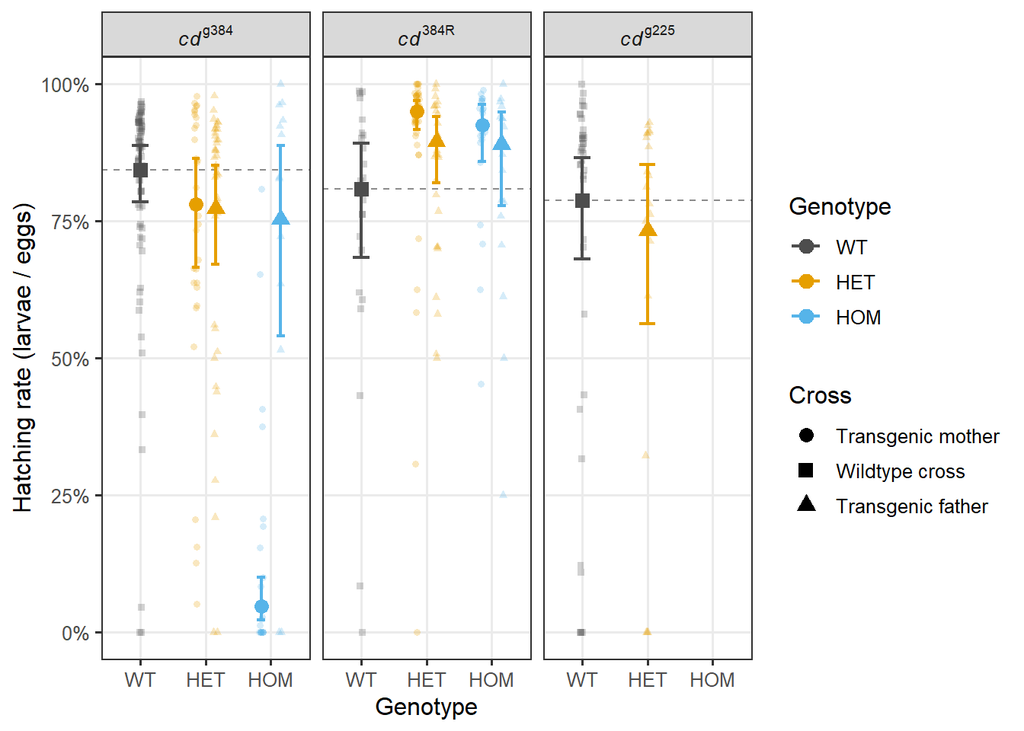

**Figure 1** (revised; comment 7).

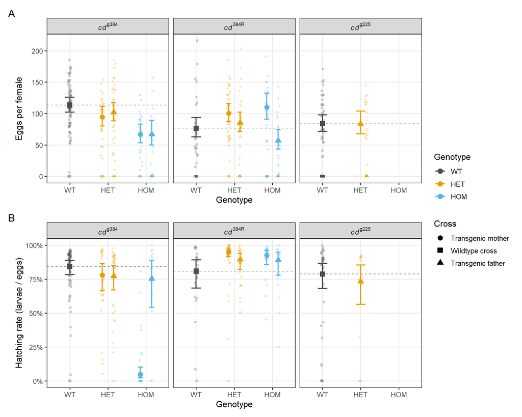

## Survival after blood feeding (STable 5; Fig. 2)

**STable 5a.** Weibull model with time ratios relative to *cd*<sup>225R</sup> homozygotes (the comparisons in the current text), with corrected standard errors (Section B1 of the revision notes).

```
`r2()` does not support models of class `flexsurvreg`.
```

|  | Surv(Hours,event) |  |  |
| --- | --- | --- | --- |
| Predictors | Estimates | CI | p |
| shape | 1.38 | 1.13 – 1.68 | **0.002** |
| scale | 1127.37 | 0.00 – Inf | 0.985 |
| *cd*<sup>g384</sup> Het | 1.49 | 0.52 – 4.21 | 0.457 |
| *cd*<sup>g384</sup> Hom | 0.40 | 0.08 – 1.90 | 0.247 |
| *cd*<sup>g384</sup> WT | 2.03 | 0.61 – 6.72 | 0.245 |
| *cd*<sup>g384del</sup> Het | 0.20 | 0.10 – 0.41 | **<0.001** |
| *cd*<sup>g384del</sup> WT | 1.19 | 0.48 – 2.94 | 0.702 |
| *cd*<sup>g338-384</sup> Het | 0.07 | 0.03 – 0.14 | **<0.001** |
| *cd*<sup>g225</sup> Het | 0.09 | 0.04 – 0.19 | **<0.001** |
| *cd*<sup>g225</sup> WT | 2.73 | 0.57 – 13.08 | 0.210 |
| *cd*<sup>225R</sup> WT | 0.70 | 0.31 – 1.58 | 0.388 |
| Observations | 337 |  |  |

Groups with no deaths are fitted out of the Weibull model (complete separation; if included they corrupt the standard errors of every other group): *cd*<sup>g338-384</sup> WT.

**STable 5b (new; comment 5).** Each heterozygous or homozygous group versus the WT siblings of the same line.

| Each Het/Hom group versus WT siblings of the same line Group | Each Het/Hom group versus WT siblings of the same line Compared with | Each Het/Hom group versus WT siblings of the same line Deaths/n (group vs comparator) | Each Het/Hom group versus WT siblings of the same line Time ratio | Each Het/Hom group versus WT siblings of the same line Lower 95% CI | Each Het/Hom group versus WT siblings of the same line Upper 95% CI | Each Het/Hom group versus WT siblings of the same line p | Each Het/Hom group versus WT siblings of the same line p (Holm) |
| --- | --- | --- | --- | --- | --- | --- | --- |
| *cd*<sup>225R</sup> Hom | *cd*<sup>225R</sup> WT | 5/38 vs 8/38 | 1.430 | 0.63400 | 3.230 | 0.388 | 0.388 |
| *cd*<sup>g384</sup> Het | *cd*<sup>g384</sup> WT | 3/37 vs 2/38 | 0.731 | 0.19900 | 2.690 | 0.637 | 0.637 |
| *cd*<sup>g384</sup> Hom | *cd*<sup>g384</sup> WT | 1/2 vs 2/38 | 0.195 | 0.03350 | 1.130 | 0.069 | 0.138 |
| *cd*<sup>g384del</sup> Het | *cd*<sup>g384del</sup> WT | 26/32 vs 5/47 | 0.166 | 0.08000 | 0.345 | <0.001 | <0.001 |
| *cd*<sup>g338-384</sup> Het | *cd*<sup>g338-384</sup> WT | 31/31 vs 0/47 | not estimable | not estimable | not estimable | not estimable | not estimable |
| *cd*<sup>g225</sup> Het | *cd*<sup>g225</sup> WT | 41/41 vs 1/33 | 0.033 | 0.00735 | 0.148 | <0.001 | <0.001 |

**Figure 2.**

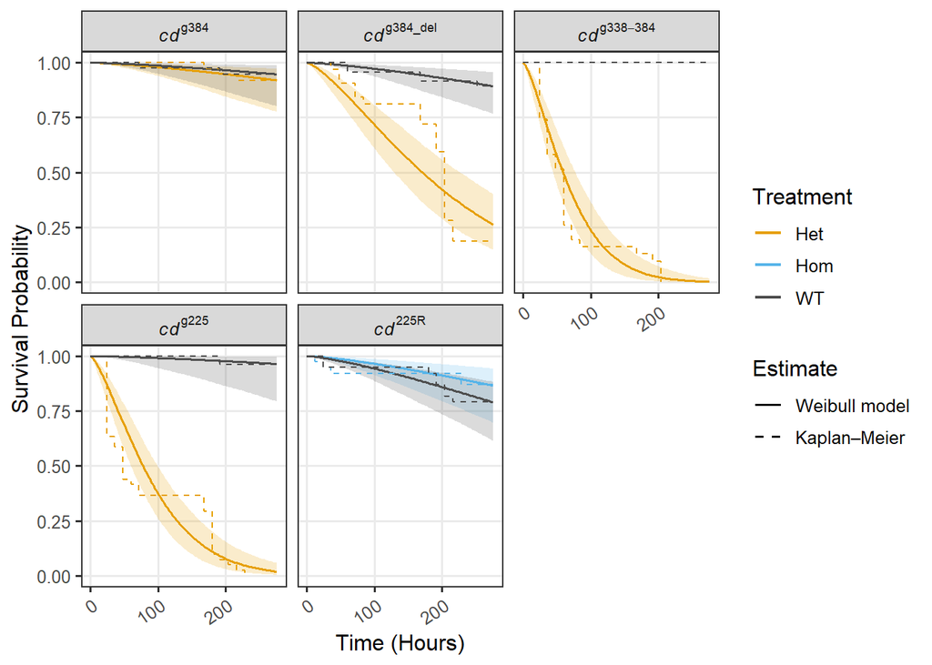

**STable 5c.** Median survival time (t50; values quoted in the text).

| Line | Genotype | Median survival time Median survival (h) | Median survival time Lower 95% CI | Median survival time Upper 95% CI |
| --- | --- | --- | --- | --- |
| *cd*<sup>g384</sup> | WT | 1,755.4 | 587.6 | 5,046.2 |
| *cd*<sup>g384</sup> | Het | 1,282.9 | 568.2 | 3,135.5 |
| *cd*<sup>g384</sup> | Hom | 342.4 | 85.7 | 1,448.5 |
| *cd*<sup>g225</sup> | WT | 2,354.6 | 520.2 | 10,600.6 |
| *cd*<sup>g225</sup> | Het | 77.6 | 61.9 | 98.8 |
| *cd*<sup>g384del</sup> | WT | 1,029.9 | 512.4 | 1,937.4 |
| *cd*<sup>g384del</sup> | Het | 171.1 | 128.9 | 221.7 |
| *cd*<sup>g338-384</sup> | Het | 58.9 | 44.7 | 77.4 |
| *cd*<sup>225R</sup> | Hom | 863.7 | 456.2 | 1,686.9 |
| *cd*<sup>225R</sup> | WT | 603.7 | 378.9 | 1,033.3 |

**STable 5d.** Survival probability at 300 h (the value for *cd*<sup>225R</sup> homozygotes is quoted in the text).

| Line | Genotype | Survival probability at 300 h Survival | Survival probability at 300 h Lower 95% CI | Survival probability at 300 h Upper 95% CI |
| --- | --- | --- | --- | --- |
| *cd*<sup>g384</sup> | WT | 0.941 | 0.767 | 0.984 |
| *cd*<sup>g384</sup> | Het | 0.910 | 0.733 | 0.970 |
| *cd*<sup>g384</sup> | Hom | 0.561 | 0.020 | 0.911 |
| *cd*<sup>g225</sup> | WT | 0.960 | 0.780 | 0.994 |
| *cd*<sup>g225</sup> | Het | 0.012 | 0.002 | 0.041 |
| *cd*<sup>g384del</sup> | WT | 0.881 | 0.746 | 0.948 |
| *cd*<sup>g384del</sup> | Het | 0.223 | 0.111 | 0.363 |
| *cd*<sup>g338-384</sup> | Het | 0.001 | 0.000 | 0.012 |
| *cd*<sup>225R</sup> | Hom | 0.851 | 0.662 | 0.931 |
| *cd*<sup>225R</sup> | WT | 0.767 | 0.581 | 0.876 |

## Trans-heterozygote survival (STable 8; Fig. 5)

**STable 8a.** Weibull model with time ratios relative to *cd*<sup>g225</sup> heterozygotes, with corrected standard errors (Section B1).

```
`r2()` does not support models of class `flexsurvreg`.
```

|  | Surv(Hours,event) |  |  |
| --- | --- | --- | --- |
| Predictors | Estimates | CI | p |
| shape | 1.335 | 1.043 – 1.709 | **0.022** |
| scale | 70.891 | 0.000 – 1947412301.594 | 0.626 |
| *cd*<sup>g225</sup> WT | 26.664 | 5.475 – 129.860 | **<0.001** |
| Trans-het (*cd*<sup>g225</sup>:*cd*<sup>225R</sup> Het) | 0.969 | 0.690 – 1.360 | 0.856 |
| Observations | 140 |  |  |

Groups: *cd*<sup>g225</sup> het and its WT siblings; *cd*<sup>g225</sup>:*cd*<sup>225R</sup> trans-het; *cd*<sup>225R</sup> het (labelled *cd*<sup>g225</sup>:*cd*<sup>225R</sup> WT; no deaths, fitted out of the model).

**STable 8b (new).** Each group versus the *cd*<sup>g225</sup> WT siblings, and trans-heterozygotes versus *cd*<sup>g225</sup> heterozygotes (the key comparison in the text, comment 3).

| Trans-het experiment: versus cd[g225] WT siblings, and trans-het versus cd[g225] het Group | Trans-het experiment: versus cd[g225] WT siblings, and trans-het versus cd[g225] het Compared with | Trans-het experiment: versus cd[g225] WT siblings, and trans-het versus cd[g225] het Deaths/n (group vs comparator) | Trans-het experiment: versus cd[g225] WT siblings, and trans-het versus cd[g225] het Time ratio | Trans-het experiment: versus cd[g225] WT siblings, and trans-het versus cd[g225] het Lower 95% CI | Trans-het experiment: versus cd[g225] WT siblings, and trans-het versus cd[g225] het Upper 95% CI | Trans-het experiment: versus cd[g225] WT siblings, and trans-het versus cd[g225] het p | Trans-het experiment: versus cd[g225] WT siblings, and trans-het versus cd[g225] het p (Holm) |
| --- | --- | --- | --- | --- | --- | --- | --- |
| *cd*<sup>g225</sup> Het | *cd*<sup>g225</sup> WT | 37/46 vs 1/46 | 0.0375 | 0.00770 | 0.183 | <0.001 | <0.001 |
| *cd*<sup>g225</sup>:*cd*<sup>225R</sup> Het | *cd*<sup>g225</sup> WT | 38/48 vs 1/46 | 0.0363 | 0.00746 | 0.177 | <0.001 | <0.001 |
| *cd*<sup>g225</sup>:*cd*<sup>225R</sup> WT | *cd*<sup>g225</sup> WT | 0/46 vs 1/46 | not estimable | not estimable | not estimable | not estimable | not estimable |
| *cd*<sup>g225</sup>:*cd*<sup>225R</sup> Het | *cd*<sup>g225</sup> Het | 38/48 vs 37/46 | 0.9690 | 0.69000 | 1.360 | 0.856 | 0.856 |

**STable 8c.** Survival probability at 100 h (values quoted in the text).

| Line | Genotype | Survival probability at 100 h Survival | Survival probability at 100 h Lower 95% CI | Survival probability at 100 h Upper 95% CI |
| --- | --- | --- | --- | --- |
| *cd*<sup>g225</sup> | Het | 0.205 | 0.107 | 0.318 |
| *cd*<sup>g225</sup> | WT | 0.980 | 0.877 | 0.997 |
| *cd*<sup>g225</sup>:*cd*<sup>225R</sup> | Het | 0.192 | 0.097 | 0.308 |

**Figure 5.**

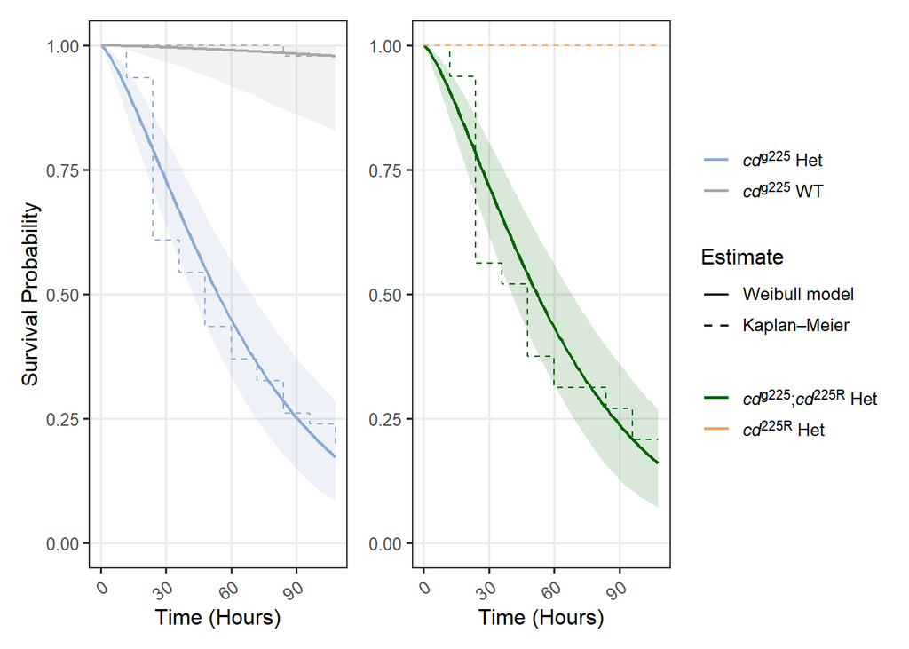

## Smurf assay (STable 6; Fig. 3C, 3D; SFig. 3)

**STable 6a.** Smurf status: binomial GLM coefficients. The KO term is not estimable (0/80 Smurf-positive), so report Fisher’s exact test instead (Table 1, STable S_fitness).

|  | cbind(positive,negative) |  |  |
| --- | --- | --- | --- |
| Predictors | Odds Ratios | CI | p |
| Intercept (WT) | 0.06 | 0.02 – 0.13 | **<0.001** |
| KI | 65.61 | 25.70 – 205.20 | **<0.001** |
| KO | 0.00 | NA – 7038073988213474278668084648826820204606688820806886606628202664862484880822844640220448220404624202080404802040482086062248880086246082646686040882404244024808006802060482264420826.00 | 0.996 |
| Observations | 9 |  |  |

**STable 6b.** Proportion of Smurf-positive females by genotype (identical to the observed proportions, as the model is saturated).

| Smurf probability by genotype Genotype | Smurf probability by genotype Probability<sup>1</sup> | Smurf probability by genotype SE | Smurf probability by genotype df | Smurf probability by genotype Lower 95% CI | Smurf probability by genotype Upper 95% CI |
| --- | --- | --- | --- | --- | --- |
| WT | 0.057 | 0.025 | Inf | 0.024 | 0.129 |
| KI | 0.798 | 0.039 | Inf | 0.710 | 0.864 |
| KO | 0.000 | 0.000 | Inf | 0.000 | 1.000 |

<sup>1</sup> Probabilities back-transformed from the logit scale. Confidence level: 95%.

**Figure 3C** (R version of the Smurf proportions; error bars are 95% CIs, not SEM).

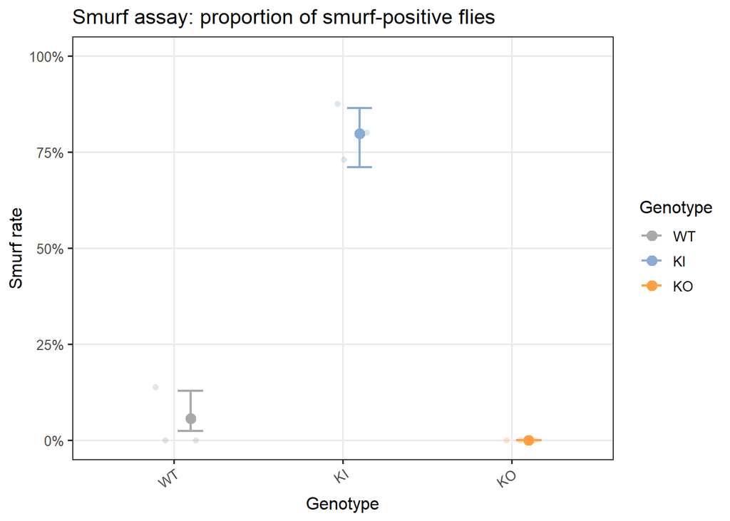

**Alternative to Figure 3C** (bar chart; not used).

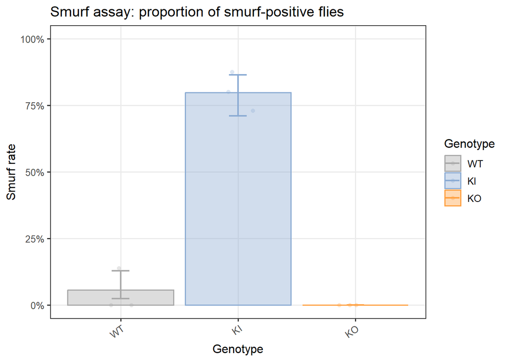

### Survival after ‘blue-feeding’ by genotype (SFig. 3)

No WT or KO females died, so the Weibull model is fitted to KI females only; WT and KO are reported as observed counts.

**STable 6c (new; suggested).** Deaths by genotype after ‘blue-feeding’. The text currently cites only SFig. 3 for these data.

[output not shown]

**Text values.** Survival of *cd*<sup>g225</sup> heterozygotes at 72 h after ‘blue-feeding’.

```
  time       est        lcl       ucl
1   72 0.1694089 0.09914744 0.2444595
```

**SFig. 3.**

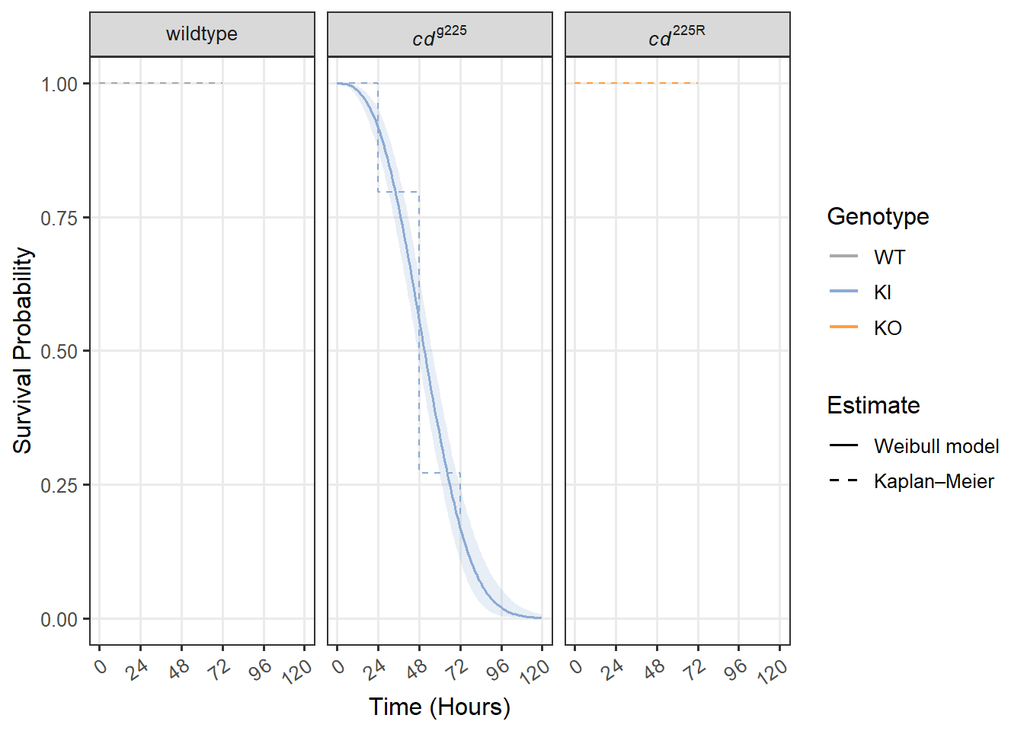

### Survival by Smurf status (Fig. 3D)

**STable 6d (new; suggested).** Weibull model of survival by Smurf status in *cd*<sup>g225</sup> heterozygotes (TR = 0.58 in the text). This is not currently in any STable.

```
`r2()` does not support models of class `flexsurvreg`.
```

|  | Surv(hours,survival) |  |  |
| --- | --- | --- | --- |
| Predictors | Estimates | CI | p |
| shape | 3.07 | 1.80 – 5.25 | **<0.001** |
| scale | 90.25 | 0.00 – 99042689238.77 | 0.672 |
| smurf [Smurf-positive] | 0.58 | 0.45 – 0.74 | **<0.001** |
| Observations | 104 |  |  |

**Text values.** Survival at 72 h by Smurf status.

```
smurf=Smurf-positive
  time        est        lcl       ucl
1   72 0.06746969 0.02831508 0.1225491

smurf=Smurf-negative
  time       est       lcl       ucl
1   72 0.6068005 0.3629519 0.7817279
```

**Figure 3D.**

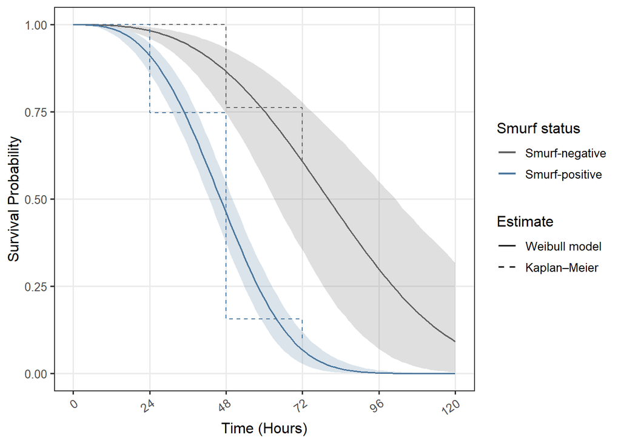

## XA supplementation (STable 7; Fig. 4)

**Superseded (original STable 7 model).** Pooled model of both routes and both genotypes, now including the WT vehicle controls. Kept for reference only: the per-route analysis below replaces it as the primary analysis (comment 4).

```
`r2()` does not support models of class `flexsurvreg`.
```

|  | Surv(Hours,event) |  |  |
| --- | --- | --- | --- |
| Predictors | Estimates | CI | p |
| shape | 2.17 | 1.27 – 3.71 | **0.004** |
| scale | 94.74 | 0.00 – 258334014336.69 | 0.681 |
| Sugar supplementation | 1.65 | 1.27 – 2.15 | **<0.001** |
| NaOH vehicle control (C-) | 0.92 | 0.69 – 1.21 | 0.534 |
| 6 mM XA | 1.64 | 1.15 – 2.35 | **0.006** |
| WT | 6.63 | 2.41 – 18.28 | **<0.001** |
| Observations | 244 |  |  |

Pooled model (both routes, both genotypes, n = 244). The WT NaOH controls are now included (previously dropped by a column-name mismatch).

### Per-route analysis of heterozygotes (reviewer comment 4)

Each treatment within a supplementation route was a single cage, so a replicate term cannot be estimated. Each route is therefore analysed separately (heterozygotes only: 1 of 112 WT females died).

**STable 7a.** Females and deaths by route, genotype and treatment.

| Genotype | Treatment | Females | Died |
| --- | --- | --- | --- |
| blood supplementation |  |  |  |
| Het | 0mM | 20 | 11 |
| Het | C- | 16 | 11 |
| Het | 6mM | 23 | 7 |
| WT | 0mM | 16 | 1 |
| WT | C- | 10 | 0 |
| WT | 6mM | 16 | 0 |
| sugar supplementation |  |  |  |
| Het | 0mM | 21 | 8 |
| Het | C- | 27 | 12 |
| Het | 6mM | 25 | 4 |
| WT | 0mM | 26 | 0 |
| WT | C- | 23 | 0 |
| WT | 6mM | 21 | 0 |

**STable 7b.** Per-route Weibull models of heterozygotes: treatment contrasts.

| Contrast | Time ratio | Lower 95% CI | Upper 95% CI | p | p (Holm, 3 contrasts) |
| --- | --- | --- | --- | --- | --- |
| blood supplementation |  |  |  |  |  |
| XA vs vehicle (C-) | 2.14 | 1.15 | 3.99 | 0.017 | 0.050 |
| XA vs untreated | 1.89 | 1.02 | 3.51 | 0.042 | 0.083 |
| C- vs untreated | 0.89 | 0.53 | 1.49 | 0.648 | 0.648 |
| sugar supplementation |  |  |  |  |  |
| XA vs vehicle (C-) | 1.36 | 1.02 | 1.82 | 0.036 | 0.107 |
| XA vs untreated | 1.28 | 0.95 | 1.72 | 0.101 | 0.202 |
| C- vs untreated | 0.94 | 0.76 | 1.16 | 0.569 | 0.569 |

**STable 7c.** Overall treatment effect within each route (likelihood-ratio test, 2 df). With three groups, unadjusted pairwise contrasts following a significant omnibus test (Fisher’s protected LSD) control the family-wise error rate.

| experiment | chisq | df | p |
| --- | --- | --- | --- |
| blood supplementation | 7.90 | 2 | 0.019 |
| sugar supplementation | 6.34 | 2 | 0.042 |

**STable 7d.** Combined across routes (heterozygotes; route as a blocking factor). Arm × treatment interaction: χ² = 0.02, df = 2, p = 0.99.

| contrast | tr | tr_lcl | tr_ucl | p_raw | p_adj |
| --- | --- | --- | --- | --- | --- |
| XA vs vehicle (C-) | 1.79 | 1.26 | 2.56 | 0.001 | 0.004 |
| XA vs untreated | 1.61 | 1.13 | 2.30 | 0.009 | 0.018 |
| C- vs untreated | 0.90 | 0.68 | 1.19 | 0.452 | 0.452 |

**STable 7e.** Survival of heterozygotes at 72 h by route and treatment (values quoted in the text).

| Treatment | Survival at 72 h | Lower 95% CI | Upper 95% CI |
| --- | --- | --- | --- |
| blood supplementation |  |  |  |
| 0mM | 55.5% | 35.3% | 74.0% |
| C- | 48.9% | 27.9% | 68.3% |
| 6mM | 81.0% | 63.9% | 90.4% |
| sugar supplementation |  |  |  |
| 0mM | 91.9% | 82.6% | 97.0% |
| C- | 89.5% | 80.4% | 95.9% |
| 6mM | 97.1% | 91.9% | 99.2% |

**Figure 4.**

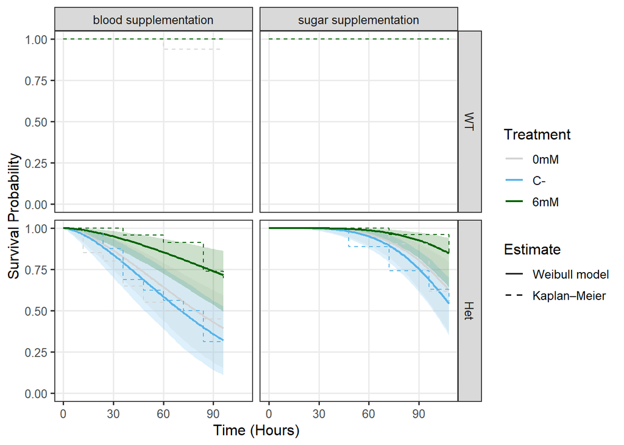

| Experiment | Dose | Genotype | Survival probability at 72 h Survival | Survival probability at 72 h Lower 95% CI | Survival probability at 72 h Upper 95% CI |
| --- | --- | --- | --- | --- | --- |
| Blood supplementation |  |  |  |  |  |
| blood supplementation | 0mM | Het | 0.577 | 0.413 | 0.734 |
| blood supplementation | 6mM | Het | 0.829 | 0.713 | 0.908 |
| blood supplementation | C- | Het | 0.513 | 0.330 | 0.688 |
| blood supplementation | 0mM | WT | 0.991 | 0.942 | 0.999 |
| blood supplementation | 6mM | WT | 0.997 | 0.979 | 1.000 |
| blood supplementation | C- | WT | 0.989 | 0.929 | 0.999 |
| Sugar supplementation |  |  |  |  |  |
| sugar supplementation | 0mM | Het | 0.831 | 0.722 | 0.906 |
| sugar supplementation | 6mM | Het | 0.939 | 0.881 | 0.973 |
| sugar supplementation | C- | Het | 0.799 | 0.686 | 0.881 |
| sugar supplementation | 0mM | WT | 0.997 | 0.980 | 1.000 |
| sugar supplementation | 6mM | WT | 0.999 | 0.992 | 1.000 |
| sugar supplementation | C- | WT | 0.996 | 0.975 | 1.000 |

## Larva-to-adult survival (STable 1)

*cd*<sup>g384</sup> homozygotes almost entirely failed to reach adulthood as females (3/400 larvae; 0.75%) and were strongly reduced as males (54/400; 13.5%), whereas *cd*<sup>384R</sup> homozygotes did not differ from WT in either sex (contrasts below).

**STable 1a (new; comments 6 and 11).** Observed larvae, pupae and adults by line, genotype and sex.

| Line | Genotype | Sex | Trays | Larvae | Pupae | Adults | Adults / larvae |
| --- | --- | --- | --- | --- | --- | --- | --- |
| *cd*<sup>g384</sup> | WT | male | 2 | 400 | 214 | 211 | 52.8% |
| *cd*<sup>g384</sup> | WT | female | 2 | 400 | 173 | 172 | 43.0% |
| *cd*<sup>g384</sup> | HET | male | 2 | 400 | 189 | 187 | 46.8% |
| *cd*<sup>g384</sup> | HET | female | 2 | 400 | 201 | 201 | 50.2% |
| *cd*<sup>g384</sup> | HOM | male | 2 | 400 | 79 | 54 | 13.5% |
| *cd*<sup>g384</sup> | HOM | female | 2 | 400 | 6 | 3 | 0.8% |
| *cd*<sup>384R</sup> | WT | male | 2 | 400 | 209 | 208 | 52.0% |
| *cd*<sup>384R</sup> | WT | female | 2 | 400 | 178 | 176 | 44.0% |
| *cd*<sup>384R</sup> | HET | male | 2 | 400 | 196 | 195 | 48.8% |
| *cd*<sup>384R</sup> | HET | female | 2 | 400 | 182 | 181 | 45.2% |
| *cd*<sup>384R</sup> | HOM | male | 2 | 400 | 182 | 181 | 45.2% |
| *cd*<sup>384R</sup> | HOM | female | 2 | 400 | 202 | 201 | 50.2% |

**STable 1b (new; comment 5).** Each genotype versus WT within line and sex (Dunnett).

| Each genotype versus WT within line and sex line | Each genotype versus WT within line and sex Sex | Each genotype versus WT within line and sex contrast | Each genotype versus WT within line and sex OR | Each genotype versus WT within line and sex Lower 95% CI | Each genotype versus WT within line and sex Upper 95% CI | Each genotype versus WT within line and sex z | Each genotype versus WT within line and sex p (Dunnett) |
| --- | --- | --- | --- | --- | --- | --- | --- |
| *cd*<sup>384R</sup> | female | HET - WT | 1.052 | 0.796 | 1.390 | 0.356 | 0.898 |
| *cd*<sup>384R</sup> | female | HOM - WT | 1.286 | 0.973 | 1.698 | 1.770 | 0.140 |
| *cd*<sup>g384</sup> | female | HET - WT | 1.339 | 1.013 | 1.769 | 2.053 | 0.075 |
| *cd*<sup>g384</sup> | female | HOM - WT | 0.010 | 0.003 | 0.032 | −7.826 | <0.001 |
| *cd*<sup>384R</sup> | male | HET - WT | 0.878 | 0.665 | 1.159 | −0.919 | 0.556 |
| *cd*<sup>384R</sup> | male | HOM - WT | 0.763 | 0.578 | 1.007 | −1.908 | 0.105 |
| *cd*<sup>g384</sup> | male | HET - WT | 0.786 | 0.596 | 1.038 | −1.696 | 0.163 |
| *cd*<sup>g384</sup> | male | HOM - WT | 0.140 | 0.099 | 0.198 | −11.097 | <0.001 |

**STable 1c.** Binomial GLM coefficients.

|  | cbind(Adults,n total-Adults) |  |  |
| --- | --- | --- | --- |
| Predictors | Odds Ratios | CI | p |
| Intercept (*cd*<sup>384R</sup> HET female) | 0.83 | 0.68 – 1.01 | 0.058 |
| Line (*cd*<sup>g384</sup> vs *cd*<sup>384R</sup>) | 1.22 | 0.93 – 1.61 | 0.157 |
| WT | 0.95 | 0.72 – 1.26 | 0.722 |
| HOM | 1.22 | 0.93 – 1.61 | 0.157 |
| Male | 1.15 | 0.87 – 1.52 | 0.321 |
| *cd*<sup>g384</sup> × WT | 0.79 | 0.53 – 1.17 | 0.230 |
| *cd*<sup>g384</sup> × HOM | 0.01 | 0.00 – 0.02 | **<0.001** |
| *cd*<sup>g384</sup> × Male | 0.76 | 0.51 – 1.12 | 0.161 |
| WT × Male | 1.20 | 0.81 – 1.78 | 0.368 |
| HOM × Male | 0.71 | 0.48 – 1.05 | 0.089 |
| *cd*<sup>g384</sup> × WT × Male | 1.42 | 0.81 – 2.48 | 0.215 |
| *cd*<sup>g384</sup> × HOM × Male | 33.42 | 10.79 – 147.54 | **<0.001** |
| Observations | 24 |  |  |

#### Contrasts

**STable 1d.** Genotype comparisons within line and sex (Tukey). This is the source of the *cd*<sup>384R</sup> ORs in the current text (HET/HOM 0.82, WT/HOM 0.78).

| contrast | line | Sex | estimate | SE | df | z.ratio | p.value | ratio | ratio.LCL | ratio.UCL |
| --- | --- | --- | --- | --- | --- | --- | --- | --- | --- | --- |
| HET - WT | *cd*<sup>384R</sup> | female | 0.0506 | 0.142 | Inf | 0.356 | 0.933 | 1.05 | 0.796 | 1.39 |
| HET - HOM | *cd*<sup>384R</sup> | female | −0.201 | 0.142 | Inf | −1.42 | 0.333 | 0.818 | 0.620 | 1.08 |
| WT - HOM | *cd*<sup>384R</sup> | female | −0.251 | 0.142 | Inf | −1.77 | 0.180 | 0.778 | 0.589 | 1.03 |
| HET - WT | *cd*<sup>g384</sup> | female | 0.292 | 0.142 | Inf | 2.05 | 0.0997 | 1.34 | 1.01 | 1.77 |
| HET - HOM | *cd*<sup>g384</sup> | female | 4.90 | 0.588 | Inf | 8.32 | <0.001 | 134 | 42.2 | 423 |
| WT - HOM | *cd*<sup>g384</sup> | female | 4.60 | 0.588 | Inf | 7.83 | <0.001 | 99.8 | 31.5 | 316 |
| HET - WT | *cd*<sup>384R</sup> | male | −0.130 | 0.142 | Inf | −0.919 | 0.628 | 0.878 | 0.665 | 1.16 |
| HET - HOM | *cd*<sup>384R</sup> | male | 0.141 | 0.142 | Inf | 0.992 | 0.582 | 1.15 | 0.872 | 1.52 |
| WT - HOM | *cd*<sup>384R</sup> | male | 0.271 | 0.142 | Inf | 1.91 | 0.136 | 1.31 | 0.993 | 1.73 |
| HET - WT | *cd*<sup>g384</sup> | male | −0.240 | 0.142 | Inf | −1.70 | 0.207 | 0.786 | 0.596 | 1.04 |
| HET - HOM | *cd*<sup>g384</sup> | male | 1.73 | 0.177 | Inf | 9.74 | <0.001 | 5.63 | 3.97 | 7.96 |
| WT - HOM | *cd*<sup>g384</sup> | male | 1.97 | 0.177 | Inf | 11.1 | <0.001 | 7.15 | 5.05 | 10.1 |

**STable 1e.** Line comparisons within genotype and sex. This is the source of OR = 1.22, p = 0.157 (shown here as its inverse, *cd*<sup>384R</sup>/*cd*<sup>g384</sup> = 0.82).

| contrast | Genotype | Sex | estimate | SE | df | z.ratio | p.value | ratio | ratio.LCL | ratio.UCL |
| --- | --- | --- | --- | --- | --- | --- | --- | --- | --- | --- |
| *cd*<sup>384R</sup> - *cd*<sup>g384</sup> | HET | female | −0.201 | 0.142 | Inf | −1.42 | 0.157 | 0.818 | 0.620 | 1.08 |
| *cd*<sup>384R</sup> - *cd*<sup>g384</sup> | WT | female | 0.0407 | 0.143 | Inf | 0.285 | 0.775 | 1.04 | 0.788 | 1.38 |
| *cd*<sup>384R</sup> - *cd*<sup>g384</sup> | HOM | female | 4.90 | 0.588 | Inf | 8.32 | <0.001 | 134 | 42.2 | 423 |
| *cd*<sup>384R</sup> - *cd*<sup>g384</sup> | HET | male | 0.0802 | 0.142 | Inf | 0.566 | 0.571 | 1.08 | 0.821 | 1.43 |
| *cd*<sup>384R</sup> - *cd*<sup>g384</sup> | WT | male | −0.0301 | 0.142 | Inf | −0.212 | 0.832 | 0.970 | 0.735 | 1.28 |
| *cd*<sup>384R</sup> - *cd*<sup>g384</sup> | HOM | male | 1.67 | 0.177 | Inf | 9.39 | <0.001 | 5.30 | 3.74 | 7.50 |

## qPCR (Fig. 6; SFig. 5)

Each line is compared with SDA-500 within sex using a linear model of ΔCt. Significance comes from a Freedman–Lane permutation test (5,000 permutations of reduced-model residuals within sex). This was corrected on 2026-11-06: the earlier version sign-flipped full-model residuals, which gave invalid p-values.

**Statistics for Fig. 6 and SFig. 5 (suggested new STable).** Each line versus SDA-500 within sex.

| Sex | contrast | Difference in ΔCt | SE | df | t | p (parametric) | p (permutation) |
| --- | --- | --- | --- | --- | --- | --- | --- |
| Cardinal_Rps7 |  |  |  |  |  |  |  |
| Female | *cd*<sup>g225</sup> - (SDA-500) | −1.80 | 0.53 | 20 | −3.39 | 0.003 | 0.001 |
| Female | *cd*<sup>g384</sup> - (SDA-500) | −0.68 | 0.53 | 20 | −1.29 | 0.213 | 0.240 |
| Female | *cd*<sup>225R</sup> - (SDA-500) | 2.97 | 0.53 | 20 | 5.59 | <0.001 | <0.001 |
| Female | *cd*<sup>384R</sup> - (SDA-500) | 3.74 | 0.53 | 20 | 7.04 | <0.001 | <0.001 |
| Male | *cd*<sup>g225</sup> - (SDA-500) | −2.62 | 0.53 | 20 | −4.94 | <0.001 | <0.001 |
| Male | *cd*<sup>g384</sup> - (SDA-500) | 0.42 | 0.53 | 20 | 0.80 | 0.435 | 0.426 |
| Male | *cd*<sup>225R</sup> - (SDA-500) | 3.33 | 0.53 | 20 | 6.27 | <0.001 | <0.001 |
| Male | *cd*<sup>384R</sup> - (SDA-500) | 2.50 | 0.53 | 20 | 4.71 | <0.001 | <0.001 |
| Cardinal_GADPH |  |  |  |  |  |  |  |
| Female | *cd*<sup>g225</sup> - (SDA-500) | −2.81 | 0.32 | 20 | −8.74 | <0.001 | <0.001 |
| Female | *cd*<sup>g384</sup> - (SDA-500) | −0.44 | 0.32 | 20 | −1.38 | 0.181 | 0.188 |
| Female | *cd*<sup>225R</sup> - (SDA-500) | 1.99 | 0.32 | 20 | 6.20 | <0.001 | <0.001 |
| Female | *cd*<sup>384R</sup> - (SDA-500) | 4.89 | 0.32 | 20 | 15.21 | <0.001 | <0.001 |
| Male | *cd*<sup>g225</sup> - (SDA-500) | −2.63 | 0.32 | 20 | −8.20 | <0.001 | <0.001 |
| Male | *cd*<sup>g384</sup> - (SDA-500) | −3.02 | 0.32 | 20 | −9.41 | <0.001 | <0.001 |
| Male | *cd*<sup>225R</sup> - (SDA-500) | 0.31 | 0.32 | 20 | 0.97 | 0.345 | 0.382 |
| Male | *cd*<sup>384R</sup> - (SDA-500) | 4.46 | 0.32 | 20 | 13.89 | <0.001 | <0.001 |

**Figure 6** (*cd* normalised to *rps7*).

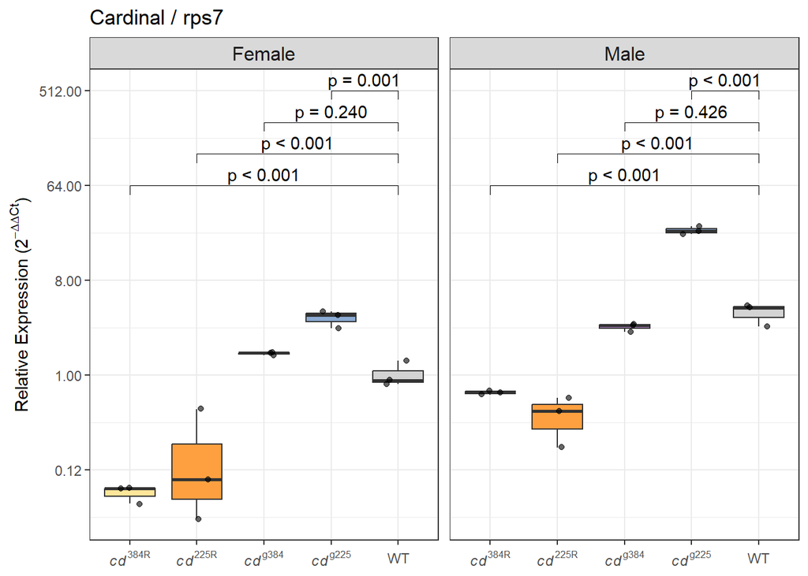

**SFig. 5** (*cd* normalised to *GAPDH*).

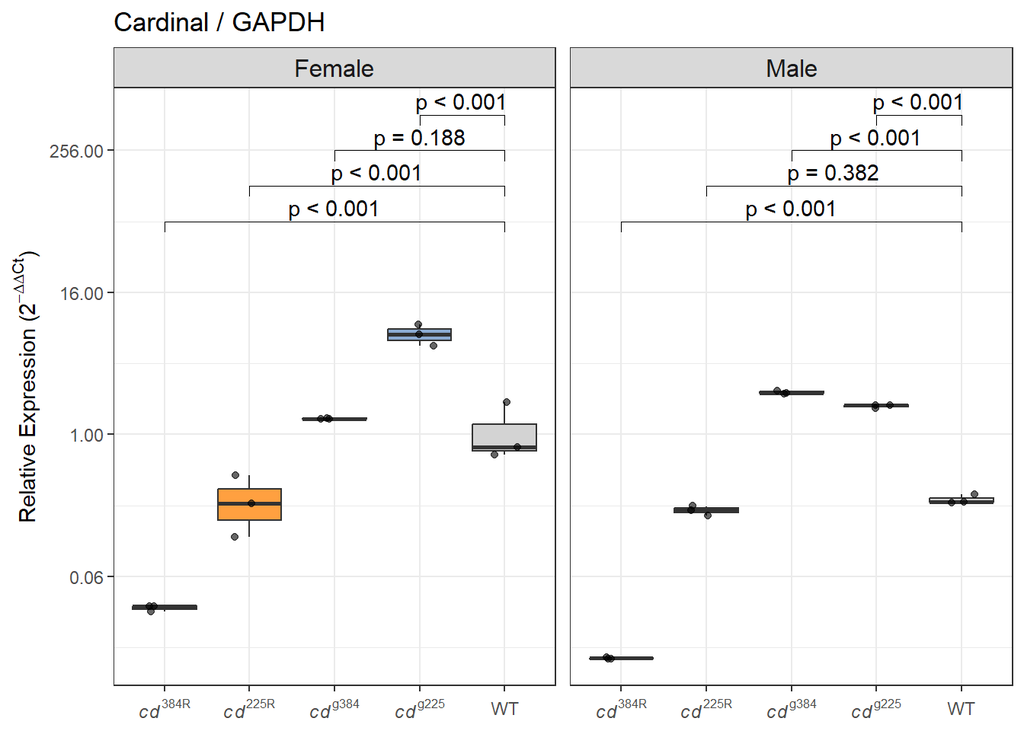

## Table 1 and STable S_fitness (new; comment 5)

**Table 1 (new, main text).** Direction and significance of each trait relative to the WT group of the same line.

**Table 1. Fitness of *cardinal* knock-in and knock-out genotypes relative to wildtype**

| Genotype | Larva-to-adult survival Females | Larva-to-adult survival Males | Fecundity (eggs per female) Transgenic mother | Fecundity (eggs per female) Transgenic father | Fertility (hatching rate) Transgenic mother | Fertility (hatching rate) Transgenic father | Survival after blood meal Females | Midgut barrier loss (Smurf+) Females |
| --- | --- | --- | --- | --- | --- | --- | --- | --- |
| Knock-in |  |  |  |  |  |  |  |  |
| *cd*<sup>g384</sup> HET | ≈ 1.3 | ≈ 0.79 | ≈ 0.83 | ≈ 0.9 | ≈ 0.66 | ≈ 0.64 | ≈ 0.73 | — |
| *cd*<sup>g384</sup> HOM | ↓ 0.01*** | ↓ 0.14*** | ↓ 0.59*** | ↓ 0.59** | ↓ 0.0094*** | ≈ 0.57 | ≈ 0.2§ | — |
| *cd*<sup>g225</sup> HET | — | — | n/e‡ | ≈ 1 | n/e‡ | ≈ 0.74 | ↓ 0.033*** | ↑ 66*** |
| *cd*<sup>g384_del</sup> HET | — | — | — | — | — | — | ↓ 0.17*** | — |
| *cd*<sup>g338-384</sup> HET | — | — | — | — | — | — | ↓ †*** | — |
| Knock-out |  |  |  |  |  |  |  |  |
| *cd*<sup>384R</sup> HET | ≈ 1.1 | ≈ 0.88 | ≈ 1.3 | ≈ 1.1 | ↑ 4.5** | ≈ 2 | — | — |
| *cd*<sup>384R</sup> HOM | ≈ 1.3 | ≈ 0.76 | ↑ 1.4* | ≈ 0.74 | ≈ 3 | ≈ 1.9 | — | — |
| *cd*<sup>225R</sup> HET | — | — | — | — | — | — | ≈ † | — |
| *cd*<sup>225R</sup> HOM | — | — | — | — | — | — | ≈ 1.4 | ≈ † |
| Trans-heterozygote |  |  |  |  |  |  |  |  |
| *cd*<sup>g225</sup>;*cd*<sup>225R</sup> | — | — | — | — | — | — | ↓ 0.036*** | — |

Each cell compares the genotype with the wildtype (WT) group of the same line and experiment: ↓/↑, significantly lower/higher than WT; ≈, no significant difference (p ≥ 0.05). The number is the effect ratio relative to WT: odds ratio (larva-to-adult survival, hatching, Smurf), rate ratio (eggs per female) or time ratio (survival after a blood meal). * p < 0.05, ** p < 0.01, *** p < 0.001 (Dunnett-adjusted within line for eclosion, fecundity and hatching; Holm-adjusted within line for survival). † Ratio not estimable because one group had no events (no deaths or no Smurf+ females); significance from a log-rank or Fisher’s exact test. ‡ Not estimable: *cd*<sup>g225</sup> heterozygous females died after blood feeding or did not feed. § Only 2 females. — Not assessed. WT groups: *cd*<sup>g384</sup> eclosion and fecundity, non-transgenic siblings; *cd*<sup>384R</sup> eclosion and fecundity, SDA-500; *cd*<sup>g225</sup> fecundity, siblings pooled with SDA-500; survival after blood feeding, non-transgenic siblings of each line (*cd*<sup>225R</sup> HET and trans-heterozygotes: *cd*<sup>g225</sup> WT siblings). Transgenic mother = transgenic female × SDA-500 male; transgenic father = SDA-500 female × transgenic male. Observed counts, 95% CIs and exact p-values are given in Supplementary Table S_fitness.

**STable S_fitness (new; number to be assigned).** Observed values, ratios with 95% CIs and p-values behind Table 1.

Supplementary Table S_fitness. Fitness traits compared with wildtype of the same line

| Genotype | Trait | Comparison | Observed | Effect | Estimate [95% CI] | p | Test | Note |
| --- | --- | --- | --- | --- | --- | --- | --- | --- |
| Knock-in |  |  |  |  |  |  |  |  |
| *cd*<sup>g384</sup> HET | Larva-to-adult survival | Females | 201/400 adults (50.2%) vs WT 172/400 (43.0%) | OR | 1.34 [1.01–1.77] | 0.075 | Dunnett |  |
| *cd*<sup>g384</sup> HET | Larva-to-adult survival | Males | 187/400 adults (46.8%) vs WT 211/400 (52.8%) | OR | 0.786 [0.596–1.04] | 0.163 | Dunnett |  |
| *cd*<sup>g384</sup> HET | Fecundity (eggs per female) | Transgenic mother | mean 77.1 eggs, 82.1% laid (n = 39) vs WT 109.3, 96.0% (n = 75) | Rate ratio | 0.832 [0.687–1.01] | 0.187 | Dunnett |  |
| *cd*<sup>g384</sup> HET | Fecundity (eggs per female) | Transgenic father | mean 89.4 eggs, 85.4% laid (n = 48) vs WT 109.3, 96.0% (n = 75) | Rate ratio | 0.898 [0.755–1.07] | 0.539 | Dunnett |  |
| *cd*<sup>g384</sup> HET | Fertility (hatching rate) | Transgenic mother | 2228/3005 eggs hatched (74.1%; n = 32) vs WT 82.1% | OR | 0.663 [0.329–1.34] | 0.589 | Dunnett |  |
| *cd*<sup>g384</sup> HET | Fertility (hatching rate) | Transgenic father | 3235/4290 eggs hatched (75.4%; n = 41) vs WT 82.1% | OR | 0.635 [0.333–1.21] | 0.445 | Dunnett |  |
| *cd*<sup>g384</sup> HET | Survival after blood meal | Females | 3/37 died vs WT 2/38 | Time ratio | 0.731 [0.199–2.69] | 0.637 | Holm |  |
| *cd*<sup>g384</sup> HOM | Larva-to-adult survival | Females | 3/400 adults (0.8%) vs WT 172/400 (43.0%) | OR | 0.01 [0.00316–0.0317] | <0.001 | Dunnett |  |
| *cd*<sup>g384</sup> HOM | Larva-to-adult survival | Males | 54/400 adults (13.5%) vs WT 211/400 (52.8%) | OR | 0.14 [0.0988–0.198] | <0.001 | Dunnett |  |
| *cd*<sup>g384</sup> HOM | Fecundity (eggs per female) | Transgenic mother | mean 53.7 eggs, 78.6% laid (n = 28) vs WT 109.3, 96.0% (n = 75) | Rate ratio | 0.587 [0.459–0.749] | <0.001 | Dunnett |  |
| *cd*<sup>g384</sup> HOM | Fecundity (eggs per female) | Transgenic father | mean 25.5 eggs, 35.1% laid (n = 37) vs WT 109.3, 96.0% (n = 75) | Rate ratio | 0.588 [0.432–0.801] | 0.003 | Dunnett |  |
| *cd*<sup>g384</sup> HOM | Fertility (hatching rate) | Transgenic mother | 260/1503 eggs hatched (17.3%; n = 22) vs WT 82.1% | OR | 0.00943 [0.0039–0.0228] | <0.001 | Dunnett |  |
| *cd*<sup>g384</sup> HOM | Fertility (hatching rate) | Transgenic father | 730/942 eggs hatched (77.5%; n = 13) vs WT 82.1% | OR | 0.57 [0.203–1.6] | 0.639 | Dunnett |  |
| *cd*<sup>g384</sup> HOM | Survival after blood meal | Females | 1/2 died vs WT 2/38 | Time ratio | 0.195 [0.0335–1.13] | 0.138 | Holm | only 2 females |
| *cd*<sup>g225</sup> HET | Fecundity (eggs per female) | Transgenic mother |  | Rate ratio | not estimable |  |  | not estimable: HET females died after blood feeding or did not feed |
| *cd*<sup>g225</sup> HET | Fecundity (eggs per female) | Transgenic father | mean 45.2 eggs, 51.3% laid (n = 39) vs WT 35.4, 40.0% (n = 95) | Rate ratio | 1 [0.767–1.31] | 0.994 | Dunnett |  |
| *cd*<sup>g225</sup> HET | Fertility (hatching rate) | Transgenic mother |  | OR | not estimable |  |  | not estimable: HET females died after blood feeding or did not feed |
| *cd*<sup>g225</sup> HET | Fertility (hatching rate) | Transgenic father | 1351/1761 eggs hatched (76.7%; n = 20) vs WT 73.7% | OR | 0.74 [0.291–1.88] | 0.526 | Dunnett |  |
| *cd*<sup>g225</sup> HET | Survival after blood meal | Females | 41/41 died vs WT 1/33 | Time ratio | 0.033 [0.00735–0.148] | <0.001 | Holm |  |
| *cd*<sup>g225</sup> HET | Midgut barrier loss (Smurf+) | Females | 83/104 Smurf+ (79.8%) vs WT 5/88 (5.7%) | OR | 65.6 [25.7–205] | <0.001 | Wald (GLM) |  |
| *cd*<sup>g384_del</sup> HET | Survival after blood meal | Females | 26/32 died vs WT 5/47 | Time ratio | 0.166 [0.08–0.345] | <0.001 | Holm |  |
| *cd*<sup>g338-384</sup> HET | Survival after blood meal | Females | 31/31 died vs WT 0/47 | Time ratio | not estimable | <0.001 | log-rank | no deaths in WT; time ratio not estimable |
| Knock-out |  |  |  |  |  |  |  |  |
| *cd*<sup>384R</sup> HET | Larva-to-adult survival | Females | 181/400 adults (45.2%) vs WT 176/400 (44.0%) | OR | 1.05 [0.796–1.39] | 0.898 | Dunnett |  |
| *cd*<sup>384R</sup> HET | Larva-to-adult survival | Males | 195/400 adults (48.8%) vs WT 208/400 (52.0%) | OR | 0.878 [0.665–1.16] | 0.556 | Dunnett |  |
| *cd*<sup>384R</sup> HET | Fecundity (eggs per female) | Transgenic mother | mean 89.5 eggs, 89.1% laid (n = 46) vs WT 57.9, 71.4% (n = 35) | Rate ratio | 1.31 [1.03–1.67] | 0.097 | Dunnett |  |
| *cd*<sup>384R</sup> HET | Fecundity (eggs per female) | Transgenic father | mean 66.7 eggs, 74.4% laid (n = 39) vs WT 57.9, 71.4% (n = 35) | Rate ratio | 1.12 [0.856–1.46] | 0.794 | Dunnett |  |
| *cd*<sup>384R</sup> HET | Fertility (hatching rate) | Transgenic mother | 3759/4118 eggs hatched (91.3%; n = 41) vs WT 80.3% | OR | 4.51 [1.91–10.7] | 0.002 | Dunnett |  |
| *cd*<sup>384R</sup> HET | Fertility (hatching rate) | Transgenic father | 2205/2603 eggs hatched (84.7%; n = 29) vs WT 80.3% | OR | 2.02 [0.808–5.07] | 0.367 | Dunnett |  |
| *cd*<sup>384R</sup> HOM | Larva-to-adult survival | Females | 201/400 adults (50.2%) vs WT 176/400 (44.0%) | OR | 1.29 [0.973–1.7] | 0.140 | Dunnett |  |
| *cd*<sup>384R</sup> HOM | Larva-to-adult survival | Males | 181/400 adults (45.2%) vs WT 208/400 (52.0%) | OR | 0.763 [0.578–1.01] | 0.105 | Dunnett |  |
| *cd*<sup>384R</sup> HOM | Fecundity (eggs per female) | Transgenic mother | mean 69.2 eggs, 62.9% laid (n = 35) vs WT 57.9, 71.4% (n = 35) | Rate ratio | 1.43 [1.09–1.88] | 0.033 | Dunnett |  |
| *cd*<sup>384R</sup> HOM | Fecundity (eggs per female) | Transgenic father | mean 38.1 eggs, 58.6% laid (n = 29) vs WT 57.9, 71.4% (n = 35) | Rate ratio | 0.743 [0.531–1.04] | 0.251 | Dunnett |  |
| *cd*<sup>384R</sup> HOM | Fertility (hatching rate) | Transgenic mother | 2139/2421 eggs hatched (88.4%; n = 22) vs WT 80.3% | OR | 2.96 [1.11–7.88] | 0.100 | Dunnett |  |
| *cd*<sup>384R</sup> HOM | Fertility (hatching rate) | Transgenic father | 996/1104 eggs hatched (90.2%; n = 17) vs WT 80.3% | OR | 1.92 [0.66–5.61] | 0.556 | Dunnett |  |
| *cd*<sup>225R</sup> HET | Survival after blood meal | Females | 0/46 died vs WT 1/46 | Time ratio | not estimable | 0.317 | log-rank | no deaths; time ratio not estimable (trans-het experiment; WT = cd[g225] siblings) |
| *cd*<sup>225R</sup> HOM | Survival after blood meal | Females | 5/38 died vs WT 8/38 | Time ratio | 1.43 [0.634–3.23] | 0.388 | Holm |  |
| *cd*<sup>225R</sup> HOM | Midgut barrier loss (Smurf+) | Females | 0/80 Smurf+ (0.0%) vs WT 5/88 (5.7%) | OR | not estimable | 0.060 | Fisher's exact | no Smurf+ females; odds ratio not estimable |
| Trans-heterozygote |  |  |  |  |  |  |  |  |
| *cd*<sup>g225</sup>;*cd*<sup>225R</sup> | Survival after blood meal | Females | 38/48 died vs WT 1/46 | Time ratio | 0.0363 [0.00746–0.177] | <0.001 | Holm | trans-het experiment; WT = cd[g225] siblings |